# SU_25_River_Rockfish_Proj_Primary_V0.4_Summary

River Mckegney

2025-08-01

## Setup, and Packages

Code Packages:

```r
# Load packages
library(gridExtra) # For using grid.table to save tables as images
library(flextable) # Alternative method to save df as image
library(tidyverse)
library(zoo)
library(lme4)
library(lmerTest)
library(rlang)
library(nortest) # For ad.test
library(car) # For homogeneity of variance with leveneTest
library(rcompanion) # For scheirerRayHare test
library(pastecs) # For stat.desc
library(ggpubr) # For assumption plots
library(conover.test) # For the conover.Iman() test function
library(DescTools) # Contain alternative ConoverTest function
library(rstatix) # tidyverse adapted stat tests and mshapiro_test() functions
library(DHARMa) # For multi-level lm models and shapiro test
library(patchwork) # For combining ggplots
```

## Data Entry: Read-in data

```r
# Read and call data into df

# Primary samples df
ABL90 <- read.csv("Raw_Data/ABL90_Raw.csv")

# River's Parturition metadata
partuition_subcat <- read.csv("Raw_Data/River's_Rockfish_Metadata_Parturition_V7.csv")
```

## Data Filtering

```r
# Data sifting: ABL90 dataset

# Step 1: Remove missing info
ABL_set1 <- ABL90 %>%
  filter(Patient.ID_edited != "")


# Step 2: Separate Patient.ID into columns of sample types: blood plasma and instant freeze plasma
ABL_set2 <- separate(ABL_set1, 'Patient.ID_edited', into = c("Patient.ID_edited", "Sample_Type"), sep = ",")
# Step 3:
# Convert Patient.ID_edited column data to character type
ABL_set2$Patient.ID_edited <- as.character(ABL_set2$Patient.ID_edited)
```

```r
# Step 4 & 5: Sussing out specific sample errors

# Remove insufficient samples
ABL_set3 <- ABL_set2 %>%
  filter(!is.na("Type")) %>%
  filter(!str_detect(Errors.detected.during.measurement, "Insufficient sample"))

# Remove inhomogeneous samples
ABL_set3 <- ABL_set3 %>%
  filter(!is.na("Type")) %>%
  filter(!str_detect(Errors.detected.during.measurement, "Inhomogeneous sample"))

# Step 6: Filter for only blood samples
ABL_b_samp <- ABL_set3 %>%
  filter(Sample_Type == "b")
```

## Merge Datasets:

Join ABL90 df with parturition_subcat df: Making ABL_merged

```r
# Rename columns to match: Change 'ID' in parturition_subcat to 'Patient.ID_edited' so it is ready to join with ABL90 df

# Please note the 'Treatment' col in parturition_subcat does not match with the finalized 'Ambient.Or.OAH' col in metadata_atresia_guide or ABL90_merged df

# Rename 'ID' col to 'patient.ID_edited'
partuition_subcat <- partuition_subcat %>%
  rename(Patient.ID_edited = ID)
```

```r
# Connect main ABL90 dataset with my (River's) sub categorized parturition metadata
# ABL_merged <- partuition_subcat %>%
# left_join(ABL_b_samp, by = "Patient.ID_edited")

ABL_merged <- ABL_b_samp %>%
inner_join(partuition_subcat, by = "Patient.ID_edited")
```

Rename Columns Neatly:

```r
# Rename Treatment & Parturition Outcome
ABL_merged <- ABL_merged %>%
  rename(Ambient.Or.OAH = Consensus_General_Treatment,
         Pregnant.Or.Atresia = Consensus_Atresia_Or_Pregnant)

# Rename Factors
ABL_merged <- ABL_merged %>%
  mutate(Pregnant.Or.Atresia = ifelse(Pregnant.Or.Atresia == "Post Parturition", "Pregnancy", Pregnant.Or.Atresia))
```

## Remove Samples: Mortalities, NA’s, or Missing Info, and Replicates

Remove Replicate ID’s

```r
# Cross Check all Columns: Cross validation to suss correct replicate row
check_params <- ABL_merged %>%
  select(Patient.ID_edited, Time, Sample.., Measuring.Mode, Ambient.Or.OAH, Pregnant.Or.Atresia, pH, Glu..mmol.L., Hct...., Na...mmol.L., Cl...mmol.L., K...mmol.L., Ca....mmol.L., pCO2..mmHg.) %>%
  filter(Patient.ID_edited == "9782D")
print(check_params)
```

```
##   Patient.ID_edited             Time Sample.. Measuring.Mode Ambient.Or.OAH
## 1             9782D 12/28/2023 10:04     1016         C 65uL        Ambient
## 2             9782D   1/9/2024 17:21      863         S 65uL        Ambient
##   Pregnant.Or.Atresia    pH Glu..mmol.L. Hct.... Na...mmol.L. Cl...mmol.L.
## 1           Pregnancy 7.348          0.5     9.8          184          149
## 2           Pregnancy 7.446          0.7    13.3          181          161
##   K...mmol.L. Ca....mmol.L. pCO2..mmHg.
## 1         2.8          1.32         4.2
## 2         2.9          1.31         6.8
```

```r
check_params <- ABL_merged %>%
  select(Patient.ID_edited, Time, Sample.., Measuring.Mode, Ambient.Or.OAH, Pregnant.Or.Atresia, pH, Glu..mmol.L., Hct...., Na...mmol.L., Cl...mmol.L., K...mmol.L., Ca....mmol.L., pCO2..mmHg.) %>%
  filter(Patient.ID_edited == "9783D")
print(check_params)
```

```
##   Patient.ID_edited            Time Sample.. Measuring.Mode Ambient.Or.OAH
## 1             9783D 1/19/2024 10:37      934         S 65uL        Ambient
## 2             9783D  1/7/2024 12:32      860         S 65uL        Ambient
##   Pregnant.Or.Atresia    pH Glu..mmol.L. Hct.... Na...mmol.L. Cl...mmol.L.
## 1           Pregnancy 7.484          1.7     0.2          175          193
## 2           Pregnancy 7.450          1.3    14.7          179          164
##   K...mmol.L. Ca....mmol.L. pCO2..mmHg.
## 1        34.5          1.29         8.5
## 2         2.5          1.30         5.3
```

```r
# Removed replicates: 9782D (2x) and 9783D (2x)
ABL_merged <- ABL_merged %>%
  filter(Sample.. != "863",
         Sample.. != "934")
```

Review Replicates:

| Row | ID | Time | Sample.. | Measuring.Mode | pH | Glu.mmol.L. | Hct…. | Na…mmol.L. | Cl…mmol.L. | K…mmol.L. | Ca.mmol.L. |
| --- | --- | --- | --- | --- | --- | --- | --- | --- | --- | --- | --- |
| 32 | 9782D | 12/28/2023 10:04 | 1016 | C 65uL | 7.348 | 0.5 | 9.8 | 184 | 149 | 2.8 | 1.32 |
| 39 | 9782D | 1/9/2024 17:21 | 863 | S 65uL | 7.446 | 0.7 | 13.3 | 181 | 161 | 2.9 | 1.31 |
| 36 | 9783D | 1/19/2024 10:37 | 934 | S 65uL | 7.484 | 1.7 | **0.2** | 175 | 193 | **34.5** | 1.29 |
| 41 | 9783D | 1/7/2024 12:32 | 860 | S 65uL | 7.450 | 1.3 | **14.7** | 179 | 164 | **2.5** | 1.30 |

Methods for replicate sample removal: Check processing date of IDs, and remove samples that do not match that date.

Case ID_9782D:

- Origianl ABL90 set contains:
- 9782D,b (Sample.. 1016, Time = 12/28/2023 10:04:00 AM)
- 9782D,p (Sample.. 1020, Time = 12/28/2023 10:25:00 AM)
- 9782D,p (Sample.. 865, Time = 1/9/2024 5:29:00 PM)
- 9782D,b (Sample.. 863, Time = 1/9/2024 5:21:00 PM)
- 2024_Fish_Metadata.csv says ID_9782D was processed 3/29/2024
- Note Processing date in metadata will not match time date stamp in ABL90 data due to the machine being reset, and innacurrate dates being automatically recorded.

Deciding info: - For ID-9782D, refer to metadata sheet and look for other samples with that same processing date, then view thoes samples ABL90 ‘Time’. Try to find a matching ‘Time’ with other IDs and 9782D that were processed together during the same time recorded by the machine.

Case ID_9783D

- Original ABL90 dataset contains:
- 9783D,b (Sample.. 934, Time = 1/19/2024 10:37:00 AM)
- 9783D,c (Sample.. 861, Time = 1/7/2024 12:38:00 PM)
- 9783D,b (Sample.. 860, Time = 1/7/2024 12:32:00 PM)
- 2024_Fish_Metadata.csv says ID_9783D was processed 3/20/2024
- Informed that ID_9783D: Sample.. 934 is a plasma sample (on account of its low hct value), remove this and **keep Sample.. 860 (parameter values appear correct)**.

# Samples: Data subsets

Remove Motalities and No info IDs and assign analysis ready data-frames:

```r
# New df with Moralities removed: Note none of these samples made it into ABL90 df anyway, so looks like they are already filtered out.
 Live_Samples <- ABL_merged %>%
  filter(Patient.ID_edited != "9780C", # Mortality
         Patient.ID_edited != "777AE", # Mortality
         Patient.ID_edited != "777CA") # Mortality after parturition


# New df with mortality and 'No info' Id's removed
 Primary_Samples <- Live_Samples %>%
   filter(Patient.ID_edited != "777A0", # No info
           Patient.ID_edited != "9782F", # No info
           Patient.ID_edited != "777B3", # No info
           Patient.ID_edited != "777AA", # No info
           Patient.ID_edited != "777DE", # No info
           Patient.ID_edited != "777CE", # No info
           Patient.ID_edited != "777A6") # No info


# New df of Only Ambient Treatment: For testing parturition success
 Ambient_Samples <- Primary_Samples %>%
   filter(Ambient.Or.OAH == "Ambient")

# New df of Fecundity Samples:
 Fecundity_Samples <- Primary_Samples %>%
   filter(Fecundity_Or_Brood_Count != "NA",
     Fecundity_Class != "NA") # removes 97706

# Fecundity samples without atresia Ids
 Fecundity_No_Atresia_Samples <- Primary_Samples %>%
   filter(All_Fecundity != "Na",
          All_Fecundity != 0)  # removes atresia IDs

# Fecundity Ambient Samples
 Amb_Fec_Samples <- Primary_Samples %>%
   filter(Ambient.Or.OAH == "Ambient",
          All_Fecundity != "NA") # removes OAH treatment samples and ID 97706

# Fecundity Ambient Samples without atresia Ids
 Amb_Fec_No_Atresia_Samples <- Primary_Samples %>%
   filter(Ambient.Or.OAH == "Ambient", # removes OAH treatment
          All_Fecundity != "NA", # removes all missing info IDs
          All_Fecundity != 0) # removes atresia IDs
```

Change Data Types:

```r
# Change Continuous Data to type to numeric, double, or factor

# Change data type of ions to factor or numeric
#glimpse(General_Samples)
#glimpse(Ambient_Samples)

Primary_Samples <- Primary_Samples %>%
  mutate(across(c(All_Fecundity, pH, Hct...., Glu..mmol.L., Na...mmol.L., Cl...mmol.L., K...mmol.L., Ca....mmol.L.), as.numeric))

Ambient_Samples <- Ambient_Samples %>%
  mutate(across(c(All_Fecundity, pH, Hct...., Glu..mmol.L., Na...mmol.L., Cl...mmol.L., K...mmol.L., Ca....mmol.L.), as.numeric))

Fecundity_Samples <- Fecundity_Samples %>%
  mutate(across(c(All_Fecundity, pH, Hct...., Glu..mmol.L., Na...mmol.L., Cl...mmol.L., K...mmol.L., Ca....mmol.L.), as.numeric))

Fecundity_No_Atresia_Samples <- Fecundity_Samples %>%
  mutate(across(c(All_Fecundity, pH, Hct...., Glu..mmol.L., Na...mmol.L., Cl...mmol.L., K...mmol.L., Ca....mmol.L.), as.numeric))

Amb_Fec_Samples <- Amb_Fec_Samples %>%
  mutate(across(c(All_Fecundity, pH, Hct...., Glu..mmol.L., Na...mmol.L., Cl...mmol.L., K...mmol.L., Ca....mmol.L.), as.numeric))

Amb_Fec_No_Atresia_Samples <- Amb_Fec_No_Atresia_Samples %>%
  mutate(across(c(All_Fecundity, pH, Hct...., Glu..mmol.L., Na...mmol.L., Cl...mmol.L., K...mmol.L., Ca....mmol.L.), as.numeric))

# glimpse(Primary_Samples)
# glimpse(Ambient_Samples)
# glimpse(Fecundity_Samples)
# glimpse(Amb_Fec_Samples)
```

## Order Factor Levels

```r
# Fecundity data

#unique(Fecundity_Samples$Fecundity_Class)

# Arrange the order of parturition categories for visualizations & tests

# Primary Samples

# Arrange Treatment
Primary_Samples$Ambient.Or.OAH <- ordered(Primary_Samples$Ambient.Or.OAH, levels = c("Ambient", "OAH"))

# Arrange Parturition outcome
Primary_Samples$Pregnant.Or.Atresia <- ordered(Primary_Samples$Pregnant.Or.Atresia, levels = c("Pregnancy", "Atresia"))

# Arrange Brood Condition
Primary_Samples$Consensus_Brood_Condition <- ordered(Primary_Samples$Consensus_Brood_Condition, levels = c("Excellent", "Normal", "Low", "Very Low", "Atresia"))

# Arrange Fecundity Class
Primary_Samples$Fecundity_Class <- ordered(Primary_Samples$Fecundity_Class, levels = c("High (>50,000)", "Low (~1,000s)", "Atresia"))

# Remove NAs from ordered character factors
Primary_Samples <- Primary_Samples %>%
  filter(Fecundity_Class != is.na(Fecundity_Class)) %>%
  filter(Consensus_Brood_Condition != is.na(Consensus_Brood_Condition))


#class(Primary_Samples$Fecundity_Class)
```

# Save filtered dataset into data-worked folder

```r
# Save merged dataset in a worked folder

write.csv(x = Primary_Samples, file = "Worked-Data/Primary_Samples")
```

## Sample Size: n

```r
# Sample Size

# Primary data: Treatment & Pregnancy outcome
primary_sample_table <- Primary_Samples %>%
  mutate(`Parturition Type` = Pregnant.Or.Atresia,
         Treatment = Ambient.Or.OAH) %>%
  group_by(Treatment,`Parturition Type`) %>%
  summarise(`n size` = n_distinct(Patient.ID_edited), .groups = "drop")
print(primary_sample_table)
```

```
## # A tibble: 4 × 3
##   Treatment `Parturition Type` `n size`
##   <ord>     <ord>                 <int>
## 1 Ambient   Pregnancy                 8
## 2 Ambient   Atresia                  13
## 3 OAH       Pregnancy                 2
## 4 OAH       Atresia                   5
```

```r
 # pdf("data-images/primary_sample_table.pdf")
 # grid.table(primary_sample_table)
 # dev.off()

 png("data-images/primary_sample_table.png")
 grid.table(primary_sample_table)
 dev.off()
```

```r
# Primary data: Fecundity Class
primary_sample_table_fecundity_class <- Primary_Samples %>% mutate(`Parturition Type` = Pregnant.Or.Atresia,
         Treatment = Ambient.Or.OAH,
         `Fecundity Rank` = Fecundity_Class) %>%
  group_by(Treatment, `Parturition Type`, `Fecundity Rank`) %>%
  summarise(`n size` = n_distinct(Patient.ID_edited), .groups = "drop")
print(primary_sample_table_fecundity_class)
```

```
## # A tibble: 5 × 4
##   Treatment `Parturition Type` `Fecundity Rank` `n size`
##   <ord>     <ord>              <ord>               <int>
## 1 Ambient   Pregnancy          High (>50,000)          4
## 2 Ambient   Pregnancy          Low (~1,000s)           4
## 3 Ambient   Atresia            Atresia                13
## 4 OAH       Pregnancy          High (>50,000)          2
## 5 OAH       Atresia            Atresia                 5
```

```r
 # pdf("data-images/primary_sample_table_fecundity_class.pdf")
 # grid.table(primary_sample_table_fecundity_class)
 # dev.off()

 png("data-images/primary_sample_table_fecundity_class.png")
 grid.table(primary_sample_table_fecundity_class)
 dev.off()
```

Neat Table of Sample Size

```r
# Primary sample size table

primary_n_tab <- data_frame(`Sample Size` = c(8, 13, 2, 5),`Treatment` = c("Ambient", "Ambient", "OAH", "OAH"), `Parturition Type` = c("Parturition", "Atresia", "Parturition", "Atresia"))
print(primary_n_tab)
```

```
## # A tibble: 4 × 3
##   `Sample Size` Treatment `Parturition Type`
##           <dbl> <chr>     <chr>
## 1             8 Ambient   Parturition
## 2            13 Ambient   Atresia
## 3             2 OAH       Parturition
## 4             5 OAH       Atresia
```

```r
set_flextable_defaults(background.color = "white")

primary_n_tab <- flextable(primary_n_tab, cwidth = 1)

save_as_image(primary_n_tab, path = "data-images/primary_n_tab.png")
```

```
## [1] "data-images/primary_n_tab.png"
```

Sample Size Barplot:

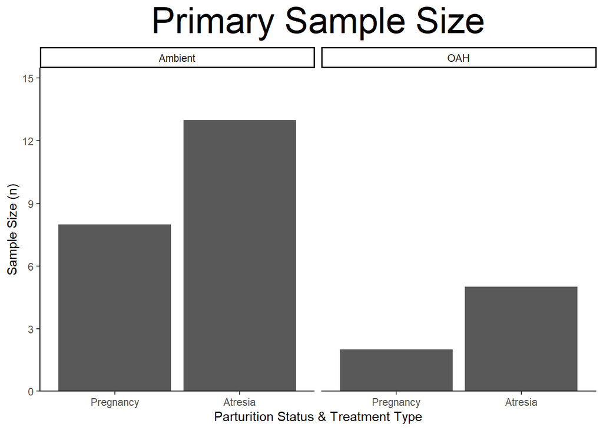

```r
# View Sample Distributions

# Sample Size barplot

# Primary Samples: General sample size
primary_sample_barplot <- Primary_Samples %>%
  group_by(Pregnant.Or.Atresia, Ambient.Or.OAH) %>%
  summarise(n_size = n_distinct(Patient.ID_edited), .groups = "drop") %>%
  ggplot(aes(x = Pregnant.Or.Atresia, y = n_size)) +
  geom_bar(stat = "identity" ) +
  scale_y_continuous(expand = c(0, 0), limits = c(0, 15.5), breaks = c(0, 3, 6, 9, 12, 15)) +
  facet_grid(~ Ambient.Or.OAH) +
  labs(title = "Primary Sample Size",
        x = "Parturition Status & Treatment Type",
        y = "Sample Size (n)") +
  guides(fill = guide_legend((title = "Reproductive State"))) +
  theme_classic() +
  theme(plot.title = element_text(size = 30, hjust = 0.5))

print(primary_sample_barplot)
```

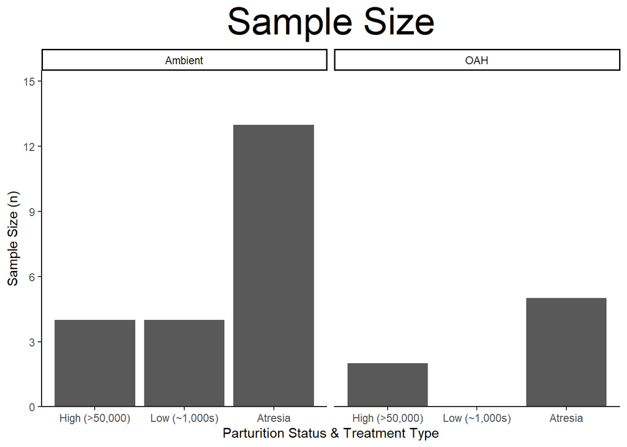

```r
ggsave(filename = "data-images/primary_sample_barplot.png", plot = primary_sample_barplot, device = "png")
ggsave(filename = "data-images/primary_sample_barplot.pdf", plot = primary_sample_barplot, device = "pdf")
# Primary samples: Fecundity Class sample size
primary_sample_fecundity_class_barplot <- Primary_Samples %>%
  group_by(Fecundity_Class, Ambient.Or.OAH) %>%
  summarise(n_size = n_distinct(Patient.ID_edited), .groups = "drop") %>%
  ggplot(aes(x = Fecundity_Class, y = n_size)) +
  geom_bar(stat = "identity" ) +
  scale_y_continuous(expand = c(0, 0), limits = c(0, 15.5), breaks = c(0, 3, 6, 9, 12, 15)) +
  facet_grid(~ Ambient.Or.OAH) +
  labs(title = "Sample Size",
        x = "Parturition Status & Treatment Type",
        y = "Sample Size (n)") +
  guides(fill = guide_legend((title = "Reproductive State"))) +
  theme_classic() +
  theme(plot.title = element_text(size = 30, hjust = 0.5))

print(primary_sample_fecundity_class_barplot)
```

```r
ggsave(filename = "data-images/primary_sample_fecundity_class_barplot.png", plot = primary_sample_barplot, device = "png")
ggsave(filename = "data-images/primary_sample_fecundity_class_barplot.pdf", plot = primary_sample_fecundity_class_barplot, device = "pdf")
```

# Carbon Dioxide

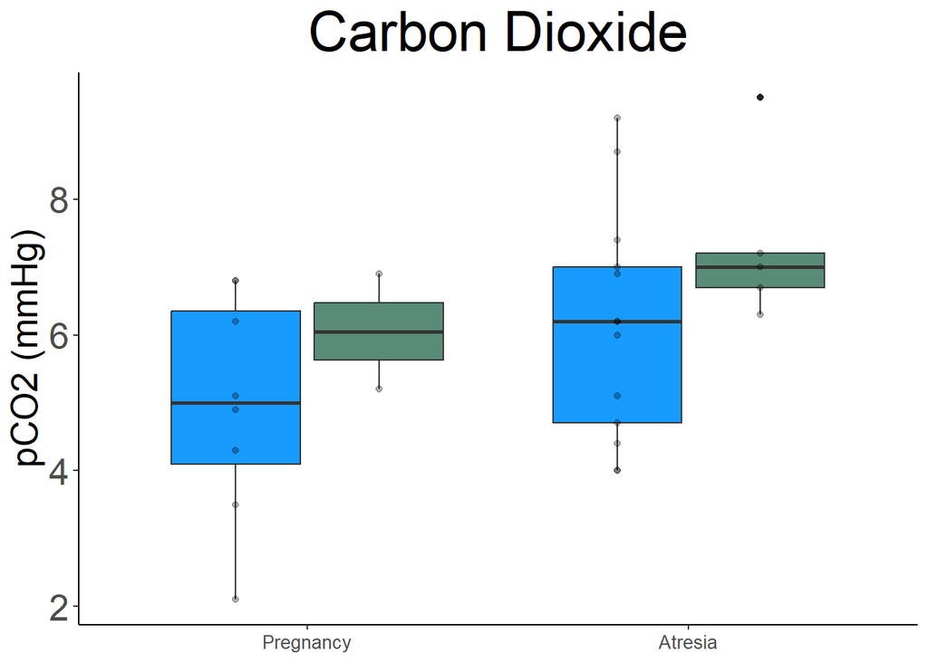

```r
# pCO2 boxplot

# Primary samples
pCO2_primary_boxplot <- ggplot(data = Primary_Samples, aes(x = Pregnant.Or.Atresia, y = pCO2..mmHg., fill = Ambient.Or.OAH)) +
  geom_boxplot(aes(x = Pregnant.Or.Atresia, y = pCO2..mmHg., fill = Ambient.Or.OAH)) +
  geom_point(aes(color = Ambient.Or.OAH), position = position_dodge(width = 0.75), alpha = 0.3, color = "black") +
  labs(title = "Carbon Dioxide", x = "Parturition Type", y = "pCO2 (mmHg)") +
  guides(fill = guide_legend((title = "Treatment Type"))) +
  scale_fill_manual(values = c("Ambient" = "#189bff", "OAH" = "#598c78")) +
  theme_classic() +
  theme(panel.background = element_rect(fill = "white"),
        plot.background = element_rect(fill = "white"),
        legend.background = element_rect(fill = "white", color = "black"),
        legend.position = "none",
        title = element_text(size = 12),
        plot.title = element_text(size = 30, hjust = 0.5),
        axis.text.x = element_text(size = 10),
        axis.text.y = element_text(size = 20),
        axis.title.x = element_blank(),
        axis.title.y = element_text(size = 20))

print(pCO2_primary_boxplot)
```

# pCO2 Stat Tests

```r
# pCO2
# Primary Samples

# Interactive aov model
pCO2_primary_aov_int <- aov(pCO2..mmHg. ~ Pregnant.Or.Atresia * Ambient.Or.OAH, data = Primary_Samples)
summary(pCO2_primary_aov_int)
```

```
##                                    Df Sum Sq Mean Sq F value Pr(>F)
## Pregnant.Or.Atresia                 1  10.73  10.735   4.223 0.0509 .
## Ambient.Or.OAH                      1   7.09   7.091   2.790 0.1079
## Pregnant.Or.Atresia:Ambient.Or.OAH  1   0.01   0.014   0.006 0.9406
## Residuals                          24  61.01   2.542
## ---
## Signif. codes:  0 '***' 0.001 '**' 0.01 '*' 0.05 '.' 0.1 ' ' 1
```

```r
# Additive model
pCO2_primary_aov_add <- aov(pCO2..mmHg. ~ Pregnant.Or.Atresia + Ambient.Or.OAH, data = Primary_Samples)
summary(pCO2_primary_aov_add)
```

```
##                     Df Sum Sq Mean Sq F value Pr(>F)
## Pregnant.Or.Atresia  1  10.73  10.735   4.398 0.0463 *
## Ambient.Or.OAH       1   7.09   7.091   2.905 0.1007
## Residuals           25  61.02   2.441
## ---
## Signif. codes:  0 '***' 0.001 '**' 0.01 '*' 0.05 '.' 0.1 ' ' 1
```

```r
# Parametric Post-Hoc: Tukey's HSD test
TukeyHSD(pCO2_primary_aov_add)
```

```
##   Tukey multiple comparisons of means
##     95% family-wise confidence level
##
## Fit: aov(formula = pCO2..mmHg. ~ Pregnant.Or.Atresia + Ambient.Or.OAH, data = Primary_Samples)
##
## $Pregnant.Or.Atresia
##                       diff        lwr      upr     p adj
## Atresia-Pregnancy 1.292222 0.02316231 2.561282 0.0462595
##
## $Ambient.Or.OAH
##                 diff        lwr      upr     p adj
## OAH-Ambient 1.157884 -0.2464158 2.562183 0.1018949
```

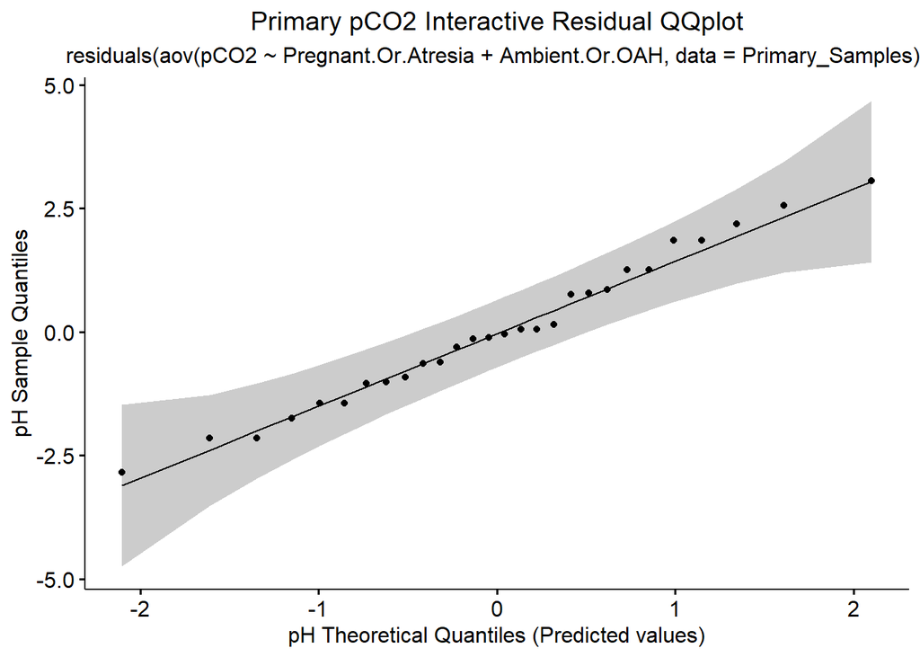

```r
# pCO2
# Parametric Tests

# Normality QQ Plot
pCO2_primary_res_qqplot <- ggqqplot(residuals(aov(pCO2..mmHg. ~ Pregnant.Or.Atresia + Ambient.Or.OAH, data = Primary_Samples))) +
labs(title = "Primary pCO2 Interactive Residual QQplot",
     subtitle = "residuals(aov(pCO2 ~ Pregnant.Or.Atresia + Ambient.Or.OAH, data = Primary_Samples))",
                               x = "pH Theoretical Quantiles (Predicted values)",
                               y = "pH Sample Quantiles") +
  theme(plot.title = element_text(hjust = 0.5),
        plot.subtitle = element_text(hjust = 0.5))
print(pCO2_primary_res_qqplot)
```

```r
# Normality Test
shapiro.test(Primary_Samples$pCO2..mmHg.)
```

```
##
##  Shapiro-Wilk normality test
##
## data:  Primary_Samples$pCO2..mmHg.
## W = 0.97288, p-value = 0.6597
```

```r
shapiro.test(residuals(aov(pCO2..mmHg. ~ Pregnant.Or.Atresia * Ambient.Or.OAH, data = Primary_Samples)))
```

```
##
##  Shapiro-Wilk normality test
##
## data:  residuals(aov(pCO2..mmHg. ~ Pregnant.Or.Atresia * Ambient.Or.OAH, data = Primary_Samples))
## W = 0.98388, p-value = 0.9308
```

```r
# Parametric variance test:
bartlett.test(pCO2..mmHg. ~ Pregnant.Or.Atresia, data = Primary_Samples)
```

```
##
##  Bartlett test of homogeneity of variances
##
## data:  pCO2..mmHg. by Pregnant.Or.Atresia
## Bartlett's K-squared = 0.016257, df = 1, p-value = 0.8985
```

```r
bartlett.test(pCO2..mmHg. ~ Ambient.Or.OAH, data = Primary_Samples)
```

```
##
##  Bartlett test of homogeneity of variances
##
## data:  pCO2..mmHg. by Ambient.Or.OAH
## Bartlett's K-squared = 0.65304, df = 1, p-value = 0.419
```

```r
# Nonparametric variance test:
LeveneTest(pCO2..mmHg. ~ Pregnant.Or.Atresia, data = Primary_Samples)
```

```
## Levene's Test for Homogeneity of Variance (center = median)
##       Df F value Pr(>F)
## group  1  0.0249 0.8759
##       26
```

```r
leveneTest(pCO2..mmHg. ~ Ambient.Or.OAH, data = Primary_Samples)
```

```
## Levene's Test for Homogeneity of Variance (center = median)
##       Df F value Pr(>F)
## group  1  1.8728 0.1829
##       26
```

Test Outliers

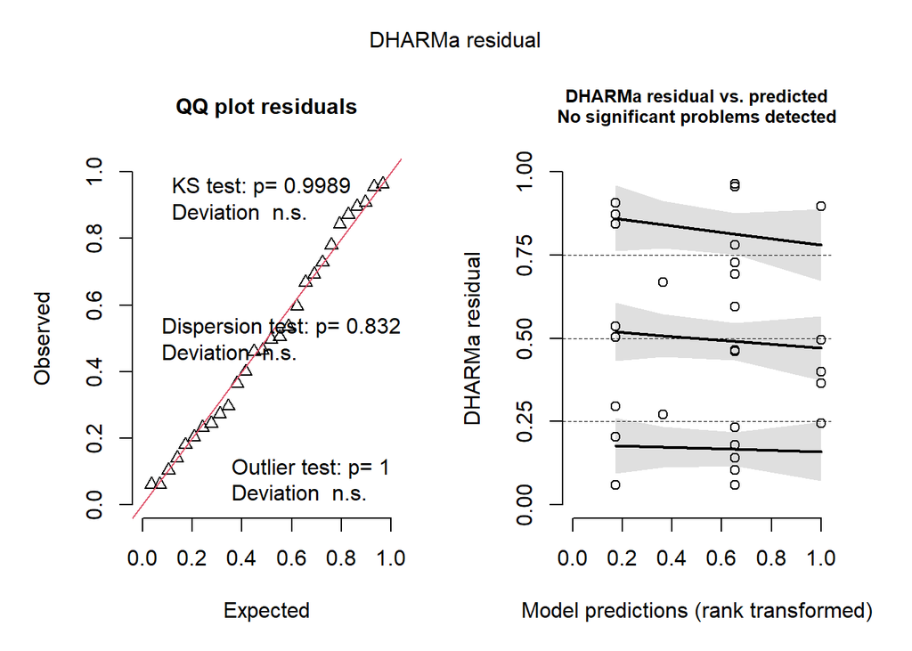

```r
# Install flexplot
# devtools::install_github("dustinfife/flexplot", ref="development")
require(flexplot)
pCO2_primary_aov_plot <- simulateResiduals(fittedModel = pCO2_primary_aov_add)
plot(pCO2_primary_aov_plot) # All good
```

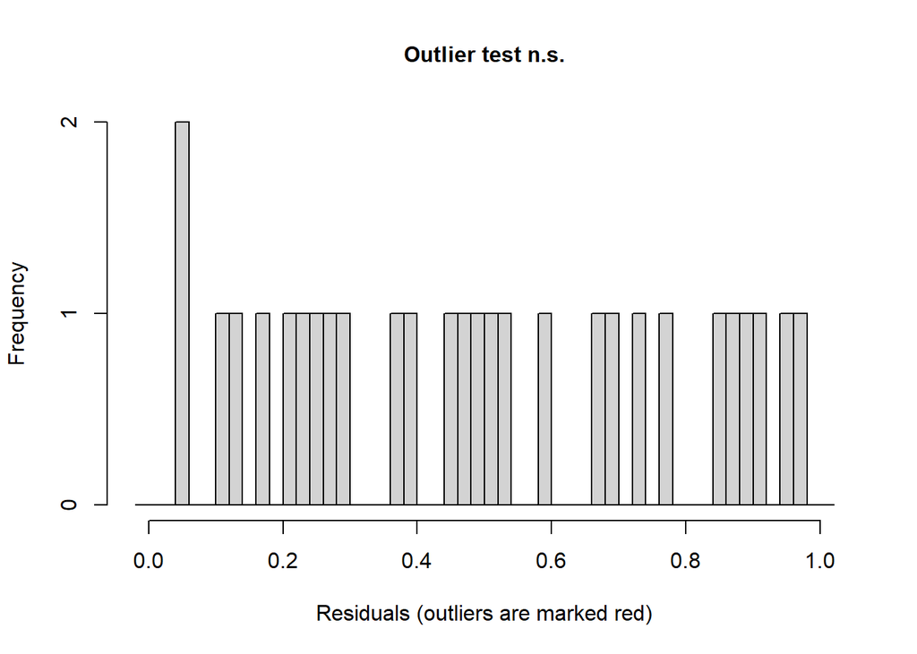

```
##
##  DHARMa outlier test based on exact binomial test with approximate
##  expectations
##
## data:  pCO2_primary_aov_plot
## outliers at both margin(s) = 0, observations = 28, p-value = 1
## alternative hypothesis: true probability of success is not equal to 0.007968127
## 95 percent confidence interval:
##  0.0000000 0.1234361
## sample estimates:
## frequency of outliers (expected: 0.00796812749003984 )
##                                                      0
```

```r
testOutliers(pCO2_primary_aov_plot)
```

# pH

pH Boxplot

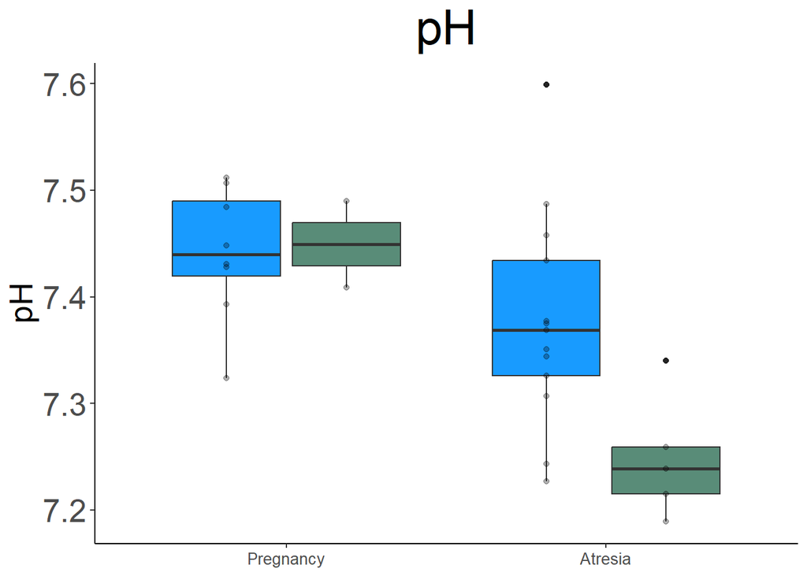

```r
# pH boxplot

# Primary samples
pH_primary_boxplot <- ggplot(data = Primary_Samples, aes(x = Pregnant.Or.Atresia, y = pH, fill = Ambient.Or.OAH)) +
  geom_boxplot(aes(x = Pregnant.Or.Atresia, y = pH, fill = Ambient.Or.OAH)) +
  geom_point(aes(color = Ambient.Or.OAH), position = position_dodge(width = 0.75), alpha = 0.3, color = "black") +
  labs(title = "pH", x = "Parturition Type", y = "pH") +
  guides(fill = guide_legend((title = "Treatment Type"))) +
  scale_fill_manual(values = c("Ambient" = "#189bff", "OAH" = "#598c78")) +
  theme_classic() +
  theme(panel.background = element_rect(fill = "white"),
        plot.background = element_rect(fill = "white"),
        legend.background = element_rect(fill = "white", color = "black"),
        legend.position = "none",
        title = element_text(size = 12),
        plot.title = element_text(size = 30, hjust = 0.5),
        axis.text.x = element_text(size = 10),
        axis.text.y = element_text(size = 20),
        axis.title.x = element_blank(),
        axis.title.y = element_text(size = 20))

print(pH_primary_boxplot)
```

# pH Stat Tests

```r
# pH
# Primary Samples

# Interactive aov model
pH_primary_aov_int <- aov(pH ~ Pregnant.Or.Atresia * Ambient.Or.OAH, data = Primary_Samples)
summary(pH_primary_aov_int) # interaction significant
```

```
##                                    Df  Sum Sq Mean Sq F value  Pr(>F)
## Pregnant.Or.Atresia                 1 0.06629 0.06629   9.638 0.00483 **
## Ambient.Or.OAH                      1 0.03877 0.03877   5.637 0.02593 *
## Pregnant.Or.Atresia:Ambient.Or.OAH  1 0.02078 0.02078   3.022 0.09495 .
## Residuals                          24 0.16506 0.00688
## ---
## Signif. codes:  0 '***' 0.001 '**' 0.01 '*' 0.05 '.' 0.1 ' ' 1
```

```r
# Additive aov model
# If interaction not significant (p-value > 0.05), use additive model

# Parametric Post-Hoc: Tukey's HSD test
TukeyHSD(pH_primary_aov_int)
```

```
##   Tukey multiple comparisons of means
##     95% family-wise confidence level
##
## Fit: aov(formula = pH ~ Pregnant.Or.Atresia * Ambient.Or.OAH, data = Primary_Samples)
##
## $Pregnant.Or.Atresia
##                         diff        lwr         upr    p adj
## Atresia-Pregnancy -0.1015444 -0.1690501 -0.03403877 0.004834
##
## $Ambient.Or.OAH
##                    diff        lwr         upr    p adj
## OAH-Ambient -0.08561481 -0.1603143 -0.01091529 0.026428
##
## $`Pregnant.Or.Atresia:Ambient.Or.OAH`
##                                          diff        lwr         upr     p adj
## Atresia:Ambient-Pregnancy:Ambient -0.06418269 -0.1669825  0.03861711 0.3345551
## Pregnancy:OAH-Pregnancy:Ambient    0.00862500 -0.1722337  0.18948366 0.9991631
## Atresia:OAH-Pregnancy:Ambient     -0.19247500 -0.3228940 -0.06205597 0.0023249
## Pregnancy:OAH-Atresia:Ambient      0.07280769 -0.1009557  0.24657107 0.6594942
## Atresia:OAH-Atresia:Ambient       -0.12829231 -0.2486791 -0.00790551 0.0337411
## Atresia:OAH-Pregnancy:OAH         -0.20110000 -0.3925028 -0.00969719 0.0369572
```

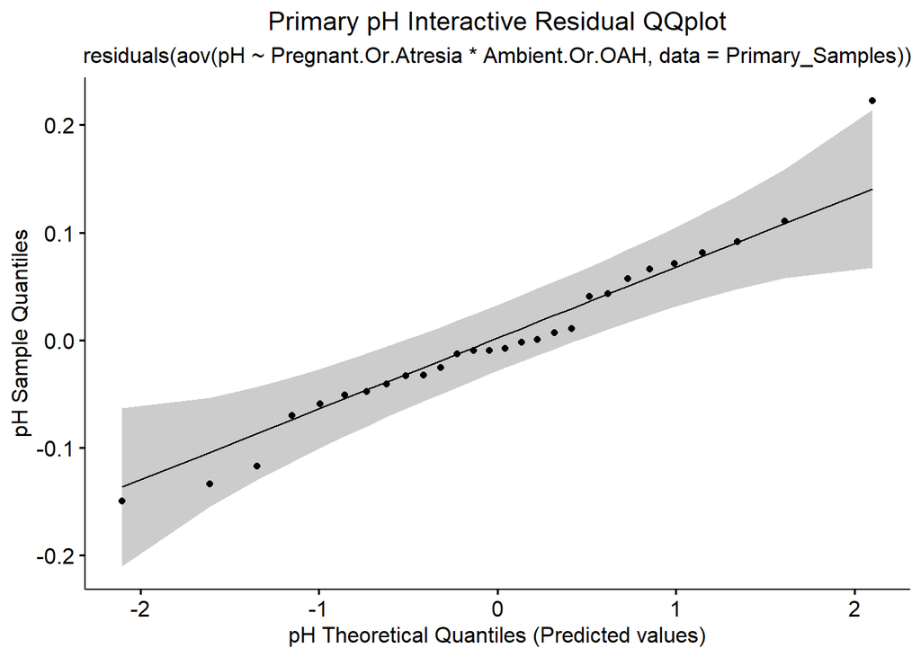

```r
# pH
# Parametric Tests

# Normality QQ Plot
pH_primary_res_qqplot <- ggqqplot(residuals(aov(pH ~ Pregnant.Or.Atresia * Ambient.Or.OAH, data = Primary_Samples))) +
labs(title = "Primary pH Interactive Residual QQplot",
     subtitle = "residuals(aov(pH ~ Pregnant.Or.Atresia * Ambient.Or.OAH, data = Primary_Samples))",
                               x = "pH Theoretical Quantiles (Predicted values)",
                               y = "pH Sample Quantiles") +
  theme(plot.title = element_text(hjust = 0.5),
        plot.subtitle = element_text(hjust = 0.5))
print(pH_primary_res_qqplot)
```

```r
# Normality Test
shapiro.test(Primary_Samples$pH)
```

```
##
##  Shapiro-Wilk normality test
##
## data:  Primary_Samples$pH
## W = 0.97662, p-value = 0.7632
```

```r
shapiro.test(residuals(aov(pH ~ Pregnant.Or.Atresia * Ambient.Or.OAH, data = Primary_Samples)))
```

```
##
##  Shapiro-Wilk normality test
##
## data:  residuals(aov(pH ~ Pregnant.Or.Atresia * Ambient.Or.OAH, data = Primary_Samples))
## W = 0.96397, p-value = 0.431
```

```r
# Parametric variance test:
bartlett.test(pH ~ Pregnant.Or.Atresia, data = Primary_Samples)
```

```
##
##  Bartlett test of homogeneity of variances
##
## data:  pH by Pregnant.Or.Atresia
## Bartlett's K-squared = 3.4356, df = 1, p-value = 0.0638
```

```r
bartlett.test(pH ~ Ambient.Or.OAH, data = Primary_Samples)
```

```
##
##  Bartlett test of homogeneity of variances
##
## data:  pH by Ambient.Or.OAH
## Bartlett's K-squared = 0.33993, df = 1, p-value = 0.5599
```

```r
# Nonparametric variance test:
LeveneTest(pH ~ Pregnant.Or.Atresia, data = Primary_Samples)
```

```
## Levene's Test for Homogeneity of Variance (center = median)
##       Df F value Pr(>F)
## group  1  2.3324 0.1388
##       26
```

```r
leveneTest(pH ~ Ambient.Or.OAH, data = Primary_Samples)
```

```
## Levene's Test for Homogeneity of Variance (center = median)
##       Df F value Pr(>F)
## group  1  0.1912 0.6655
##       26
```

Test Outliers

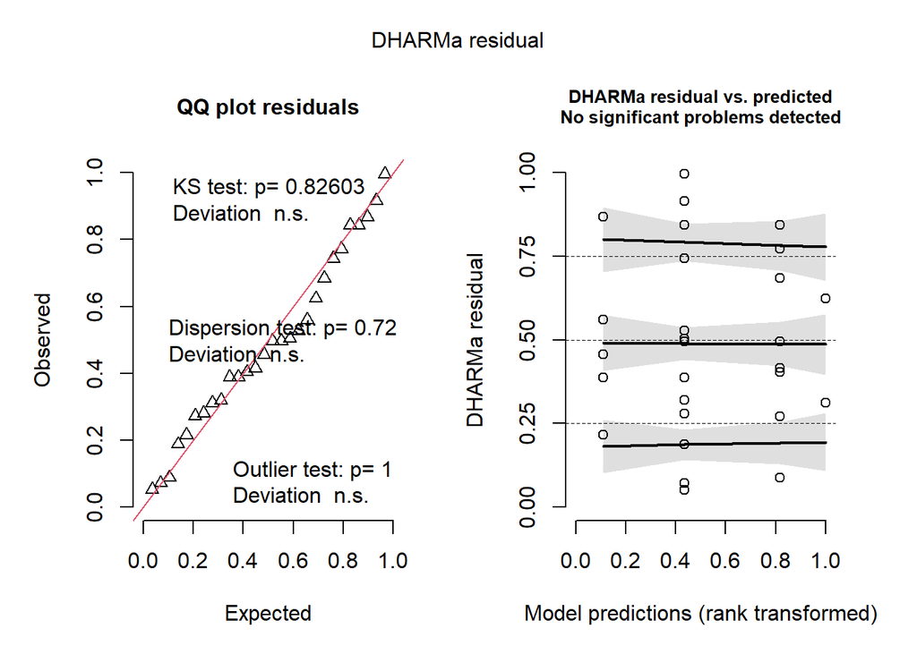

```r
# Install flexplot
# devtools::install_github("dustinfife/flexplot", ref="development")
require(flexplot)

pH_primary_aov_plot <- simulateResiduals(fittedModel = pH_primary_aov_int)
plot(pH_primary_aov_plot) # Looks good
```

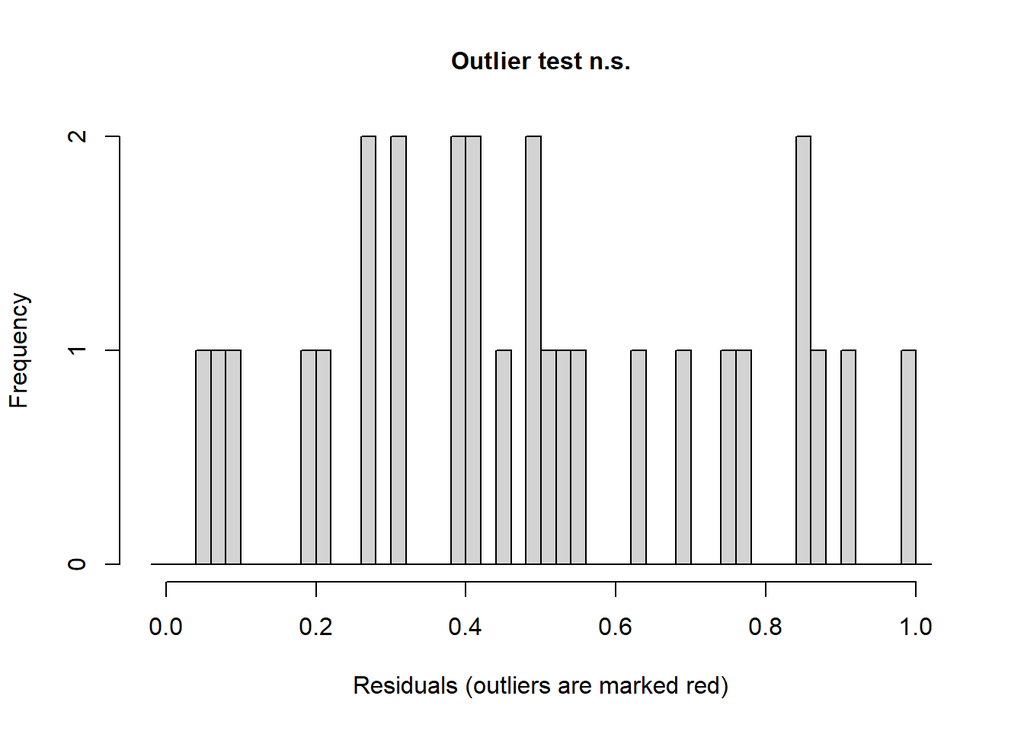

```
##
##  DHARMa outlier test based on exact binomial test with approximate
##  expectations
##
## data:  pH_primary_aov_plot
## outliers at both margin(s) = 0, observations = 28, p-value = 1
## alternative hypothesis: true probability of success is not equal to 0.007968127
## 95 percent confidence interval:
##  0.0000000 0.1234361
## sample estimates:
## frequency of outliers (expected: 0.00796812749003984 )
##                                                      0
```

```r
testOutliers(pH_primary_aov_plot)
```

# Hematocrit

Hct Boxplot

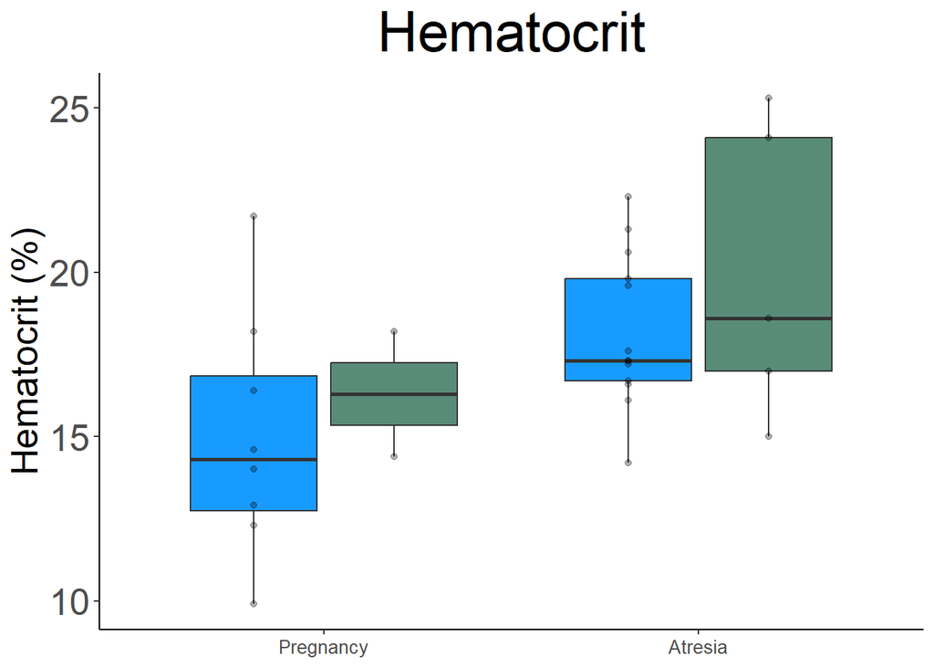

```r
# hct boxplot

# Primary samples
hct_primary_boxplot <- ggplot(data = Primary_Samples, aes(x = Pregnant.Or.Atresia, y = Hct...., fill = Ambient.Or.OAH)) +
  geom_boxplot(aes(x = Pregnant.Or.Atresia, y = Hct...., fill = Ambient.Or.OAH)) +
  geom_point(aes(color = Ambient.Or.OAH), position = position_dodge(width = 0.75), alpha = 0.3, color = "black") +
  labs(title = "Hematocrit", x = "Parturition Type", y = "Hematocrit (%)") +
  guides(fill = guide_legend((title = "Treatment Type"))) +
  scale_fill_manual(values = c("Ambient" = "#189bff", "OAH" = "#598c78")) +
  theme_classic() +
  theme(panel.background = element_rect(fill = "white"),
        plot.background = element_rect(fill = "white"),
        legend.background = element_rect(fill = "white", color = "black"),
        title = element_text(size = 12),
        plot.title = element_text(size = 30, hjust = 0.5), legend.position = "none",
        axis.text.x = element_text(size = 10),
        axis.text.y = element_text(size = 20),
        axis.title.x = element_blank(),
        axis.title.y = element_text(size = 20))

print(hct_primary_boxplot)
```

# Hematocrit Stat Tests

```r
# hct
# Primary Samples

# Interactive aov model
hct_primary_aov_int <- aov(Hct.... ~ Pregnant.Or.Atresia * Ambient.Or.OAH, data = Primary_Samples)
summary(hct_primary_aov_int)
```

```
##                                    Df Sum Sq Mean Sq F value Pr(>F)
## Pregnant.Or.Atresia                 1  76.07   76.07   7.334 0.0123 *
## Ambient.Or.OAH                      1  14.13   14.13   1.362 0.2547
## Pregnant.Or.Atresia:Ambient.Or.OAH  1   0.28    0.28   0.027 0.8715
## Residuals                          24 248.94   10.37
## ---
## Signif. codes:  0 '***' 0.001 '**' 0.01 '*' 0.05 '.' 0.1 ' ' 1
```

```r
# Additive aov model
# If interaction not significant (p-value > 0.05), use additive model
hct_primary_aov_additive <- aov(Hct.... ~ Pregnant.Or.Atresia + Ambient.Or.OAH, data = Primary_Samples)
summary(hct_primary_aov_additive)
```

```
##                     Df Sum Sq Mean Sq F value Pr(>F)
## Pregnant.Or.Atresia  1  76.07   76.07   7.631 0.0106 *
## Ambient.Or.OAH       1  14.13   14.13   1.417 0.2451
## Residuals           25 249.22    9.97
## ---
## Signif. codes:  0 '***' 0.001 '**' 0.01 '*' 0.05 '.' 0.1 ' ' 1
```

```r
# Parametric Post-Hoc: Tukey's HSD test
TukeyHSD(hct_primary_aov_additive)
```

```
##   Tukey multiple comparisons of means
##     95% family-wise confidence level
##
## Fit: aov(formula = Hct.... ~ Pregnant.Or.Atresia + Ambient.Or.OAH, data = Primary_Samples)
##
## $Pregnant.Or.Atresia
##                   diff       lwr      upr     p adj
## Atresia-Pregnancy 3.44 0.8753289 6.004671 0.0106014
##
## $Ambient.Or.OAH
##                 diff       lwr      upr     p adj
## OAH-Ambient 1.634286 -1.203694 4.472265 0.2467681
```

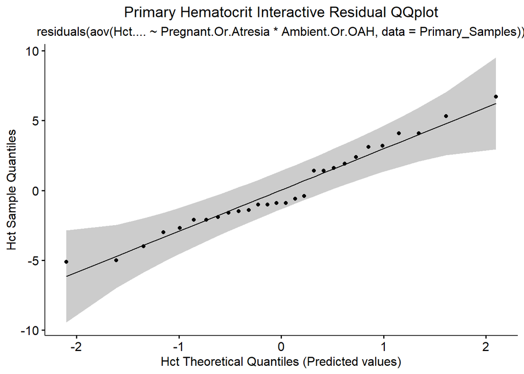

```r
# pH
# Parametric Tests

# Normality QQ plot
hct_primary_res_qqplot <- ggqqplot(residuals(aov(Hct.... ~ Pregnant.Or.Atresia * Ambient.Or.OAH, data = Primary_Samples))) +
labs(title = "Primary Hematocrit Interactive Residual QQplot",
     subtitle = "residuals(aov(Hct.... ~ Pregnant.Or.Atresia * Ambient.Or.OAH, data = Primary_Samples))",
                               x = "Hct Theoretical Quantiles (Predicted values)",
                               y = "Hct Sample Quantiles") +
  theme(plot.title = element_text(hjust = 0.5),
        plot.subtitle = element_text(hjust = 0.5))
print(hct_primary_res_qqplot)
```

```r
# Normality Test
shapiro.test(Primary_Samples$Hct....)
```

```
##
##  Shapiro-Wilk normality test
##
## data:  Primary_Samples$Hct....
## W = 0.9866, p-value = 0.9687
```

```r
shapiro.test(residuals(lm(Hct.... ~ Pregnant.Or.Atresia * Ambient.Or.OAH, data = Primary_Samples)))
```

```
##
##  Shapiro-Wilk normality test
##
## data:  residuals(lm(Hct.... ~ Pregnant.Or.Atresia * Ambient.Or.OAH, data = Primary_Samples))
## W = 0.96395, p-value = 0.4305
```

```r
# Parametric variance test:
bartlett.test(Hct.... ~ Pregnant.Or.Atresia, data = Primary_Samples)
```

```
##
##  Bartlett test of homogeneity of variances
##
## data:  Hct.... by Pregnant.Or.Atresia
## Bartlett's K-squared = 0.16489, df = 1, p-value = 0.6847
```

```r
bartlett.test(Hct.... ~ Ambient.Or.OAH, data = Primary_Samples)
```

```
##
##  Bartlett test of homogeneity of variances
##
## data:  Hct.... by Ambient.Or.OAH
## Bartlett's K-squared = 0.66339, df = 1, p-value = 0.4154
```

```r
# Nonparametric variance test:
LeveneTest(Hct.... ~ Pregnant.Or.Atresia, data = Primary_Samples)
```

```
## Levene's Test for Homogeneity of Variance (center = median)
##       Df F value Pr(>F)
## group  1  0.0702 0.7932
##       26
```

```r
leveneTest(Hct.... ~ Ambient.Or.OAH, data = Primary_Samples)
```

```
## Levene's Test for Homogeneity of Variance (center = median)
##       Df F value Pr(>F)
## group  1  0.3941 0.5356
##       26
```

Test Outliers

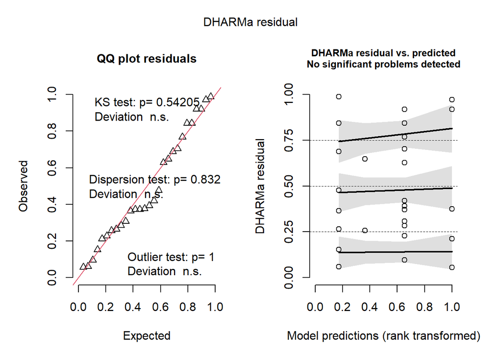

```r
hct_primary_aov_plot <- simulateResiduals(fittedModel = hct_primary_aov_additive)
plot(hct_primary_aov_plot) # Looks good
```

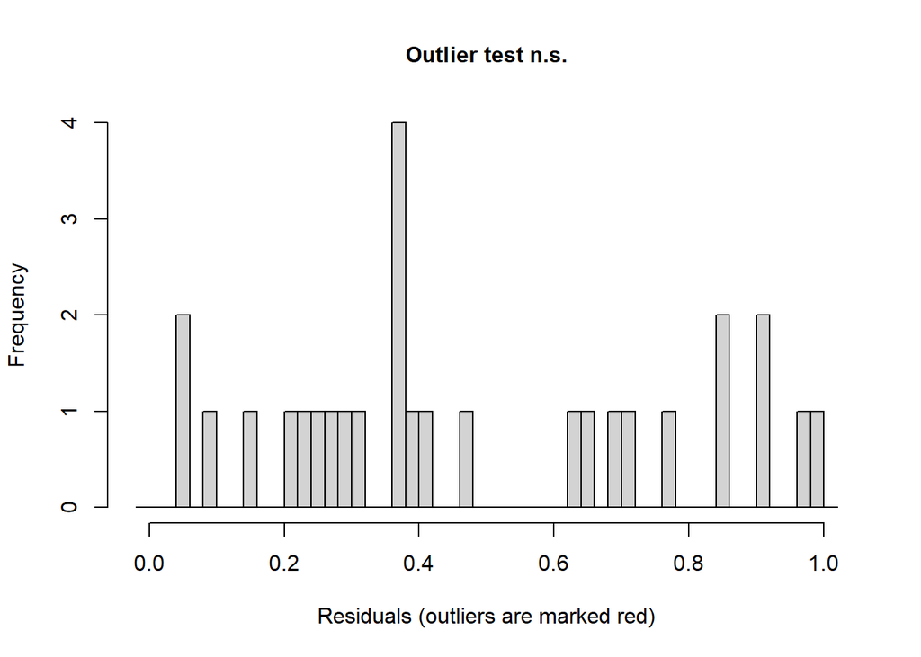

```
##
##  DHARMa outlier test based on exact binomial test with approximate
##  expectations
##
## data:  hct_primary_aov_plot
## outliers at both margin(s) = 0, observations = 28, p-value = 1
## alternative hypothesis: true probability of success is not equal to 0.007968127
## 95 percent confidence interval:
##  0.0000000 0.1234361
## sample estimates:
## frequency of outliers (expected: 0.00796812749003984 )
##                                                      0
```

```r
testOutliers(hct_primary_aov_plot)
```

```r
# Remove Outlier
# hct_outlier_removed <- Primary_Samples %>%
#   filter()
#
# # Test again
#
# # Interactive aov model
# hct_primary_aov_int2 <- aov(Hct.... ~ Pregnant.Or.Atresia * Ambient.Or.OAH, data = hct_outlier_removed)
# summary(hct_primary_aov_int2)
#
# hct_primary_aov_plot2 <- simulateResiduals(fittedModel = hct_primary_aov_int2)
# plot(hct_primary_aov_plot2)
#
# testOutliers(hct_primary_aov_plot2)
```

# Glucose

Glucose Boxplot

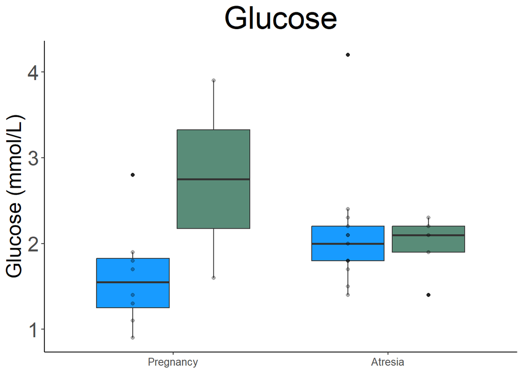

```r
# glucose boxplot

# Primary samples
glucose_primary_boxplot <- ggplot(data = Primary_Samples, aes(x = Pregnant.Or.Atresia, y = Glu..mmol.L., fill = Ambient.Or.OAH)) +
  geom_boxplot(aes(x = Pregnant.Or.Atresia, y = Glu..mmol.L., fill = Ambient.Or.OAH)) +
  geom_point(aes(color = Ambient.Or.OAH), position = position_dodge(width = 0.75), alpha = 0.3, color = "black") +
  labs(title = "Glucose", x = "Parturition Type", y = "Glucose (mmol/L)") +
  guides(fill = guide_legend((title = "Treatment Type"))) +
  scale_fill_manual(values = c("Ambient" = "#189bff", "OAH" = "#598c78")) +
  theme_classic() +
  theme(panel.background = element_rect(fill = "white"),
        plot.background = element_rect(fill = "white"),
        legend.background = element_rect(fill = "white", color = "black"),
        title = element_text(size = 12),
        plot.title = element_text(size = 30, hjust = 0.5), legend.position = "none",
        axis.text.x = element_text(size = 10),
        axis.text.y = element_text(size = 20),
        axis.title.x = element_blank(),
        axis.title.y = element_text(size = 20))

print(glucose_primary_boxplot)
```